# Allometric Scaling — OLS vs SMA vs PGLS Analysis

plant_scaling_data project

2026-05-02

```r
results_table    <- readRDS(file.path(proj_dir, "data/processed/pgls_results_table.rds"))
phylosig_table   <- readRDS(file.path(proj_dir, "data/processed/phylosig_table.rds"))
ne_species_means <- readRDS(file.path(proj_dir, "data/processed/ne_species_means.rds"))
baad_species_means <- readRDS(file.path(proj_dir, "data/processed/baad_species_means.rds"))
pruned_tree      <- readRDS(file.path(proj_dir, "data/processed/pgls_tree_smith2018_s2.rds"))
```

# 1 Overview

This report documents the phylogenetically informed allometric scaling analysis for two plant datasets. Three regression methods are compared for each scaling relationship: OLS, SMA, and PGLS.

**Datasets:**

| Dataset | N records | Aggregation unit | Primary source |
| --- | --- | --- | --- |
| Niklas-Enquist | ~2,626 cross-species records | Species means (geometric mean of log10 values) | Cannell (1982) and primary literature compiled by Niklas & Enquist (2001) |
| BAAD | ~21,084 individual-level records | Species means (geometric mean of log10 values) | Falster et al. (2015) |

For PGLS, both datasets were aggregated to species means by taking the arithmetic mean of log10-transformed values, which is equivalent to the geometric mean in the original scale.

**Regression methods:**

- **OLS** (ordinary least squares): treats each species as independent; ignores phylogenetic relatedness.
- **SMA** (standardized major axis): accounts for measurement error in both variables but still ignores phylogeny. Preferred over OLS for allometric estimation when both axes carry error.
- **PGLS** (phylogenetic generalised least squares, `caper::pgls`): corrects for phylogenetic non-independence by modelling the expected covariance among species via the variance-covariance matrix of the pruned phylogeny. Pagel’s lambda (λ) is estimated by maximum likelihood to scale the off-diagonal covariances.

**Phylogeny:** Smith & Brown (2018) GBOTB seed plant megatree, pruned to study species via V.PhyloMaker2 (Scenario 2).

**WBE theoretical predictions (West, Brown & Enquist 1997):**

- $\text{AGB} \sim H^{8/3} \approx 2.67$
- $\frac{dM}{dt} \sim M^{3/4}$
- leaf biomass $\sim$ total biomass$^{3/4}$
- $H \sim \text{DBH}^{2/3}$

# 2 Phylogeny

```r
cat("Tree tips:      ", ape::Ntip(pruned_tree), "\n")
```

```
## Tree tips:       429
```

```r
cat("Ultrametric:    ", ape::is.ultrametric(pruned_tree, tol = 1e-5), "\n")
```

```
## Ultrametric:     TRUE
```

```r
match_path <- file.path(proj_dir, "data/processed/pgls_tree_match_table.csv")
if (file.exists(match_path)) {
  match_tbl <- read_csv(match_path, show_col_types = FALSE)
  knitr::kable(match_tbl, caption = "Species-to-tree tip match summary.")
} else {
  ne_in_tree   <- nrow(ne_species_means[ne_species_means$taxa %in% pruned_tree$tip.label, ])
  baad_in_tree <- nrow(baad_species_means[baad_species_means$speciesMatched %in% pruned_tree$tip.label, ])
  knitr::kable(
    tibble(
      dataset        = c("Niklas-Enquist", "BAAD"),
      species_in_data = c(nrow(ne_species_means), nrow(baad_species_means)),
      species_in_tree = c(ne_in_tree, baad_in_tree)
    ),
    caption = "Species matched to pruned phylogeny per dataset."
  )
}
```

Species-to-tree tip match summary.

| species | species_underscore | in_tree |
| --- | --- | --- |
| Abies alba | Abies_alba | TRUE |
| Abies amabilis with some Abies procera, Tsuga heterophylla, Tsuga mertensiana | Abies_amabilis_with_some_Abies_procera,_Tsuga_heterophylla,_Tsuga_mertensiana | TRUE |
| Abies balsamea (89-98%) [a], Picea mariana and Picea glauca (0-10%) [a], Betula papyrifera and Betula alleghaniensis (1-5%) | Abies_balsamea_(89-98%)*[a],*Picea_mariana_and_Picea_glauca*(0-10%)*[a],*Betula_papyrifera_and_Betula_alleghaniensis*(1-5%) | TRUE |
| Abies firma, Cyclobalanopsis spp., Actinodaphne lancifolia et al. | Abies_firma,_Cyclobalanopsis_spp.,_Actinodaphne_lancifolia_et_al. | TRUE |
| Abies veitchii | Abies_veitchii | TRUE |
| Abies veitchii (58%) [a] and Abies mariesii (30%) et al. | Abies_veitchii_(58%)_[a]*and_Abies_mariesii*(30%)_et_al. | TRUE |
| Acacia dealbata | Acacia_dealbata | TRUE |
| Acacia harpophylla with a few Geijera parviflora | Acacia_harpophylla_with_a_few_Geijera_parviflora | TRUE |
| Acacia mollissima | Acacia_mollissima | TRUE |
| Aesculus octandra (40%) [a], Tilia heteroophylla (26%) [a], Prunus serotina (16%) [a] et al. | Aesculus_octandra_(40%)*[a],*Tilia_heteroophylla*(26%)*[a],*Prunus_serotina*(16%)_[a]_et_al. | TRUE |
| Alnus incana subsp. Tenufolia (83-89%) [a] with Salix spp. | Alnus_incana_subsp._Tenufolia_(83-89%)_[a]_with_Salix_spp. | TRUE |
| Alnus rubra | Alnus_rubra | TRUE |
| Anogeissus latifolia, Diospyros melanoxylon, Buchania lanzan, Pterocarpus marsupium et al. | Anogeissus_latifolia,_Diospyros_melanoxylon,_Buchania_lanzan,_Pterocarpus_marsupium_et_al. | FALSE |
| Betula pendula | Betula_pendula | TRUE |
| Betula pubescens (84%) [a], Betula verrucosa (16%) | Betula_pubescens_(84%)_[a],*Betula_verrucosa*(16%) | TRUE |
| Betula pubescens (B. pubescens x B. glandulosa) | Betula_pubescens_(B._pubescens_x_B._glandulosa) | TRUE |
| Betula verrucosa syn. pendula (77-96%) [a] and Betula pubescens | Betula_verrucosa_syn._pendula_(77-96%)_[a]_and_Betula_pubescens | TRUE |
| Brachystegia boehmii, Pterocarpus angolensis, Marquesia macroura, et al. | Brachystegia_boehmii,_Pterocarpus_angolensis,_Marquesia_macroura,_et_al. | TRUE |
| Camellia sinensis (tea) | Camellia_sinensis_(tea) | TRUE |
| Carapa prcera | Carapa_prcera | TRUE |
| Chamaecyparis obtusa | Chamaecyparis_obtusa | TRUE |
| Cryptomeria japonica | Cryptomeria_japonica | TRUE |
| Cupressus pygmaea (68%) [a], Vaccinium ovatum (17%) [a], Pinus contorta subsp. bolanderi (9%) | Cupressus_pygmaea_(68%)*[a],*Vaccinium_ovatum*(17%)*[a],*Pinus_contorta_subsp._bolanderi*(9%) | TRUE |
| Cyclobalanopsis spp. (esp C. gilba) and Castanopsis spp. (esp. C. cuspidata) | Cyclobalanopsis_spp._(esp_C._gilba)*and_Castanopsis_spp.*(esp._C._cuspidata) | FALSE |
| Dacryodes excelsa (ca.35%) [a], Sloanea berteriana, Manilkara bidentata et al. | Dacryodes_excelsa_(ca.35%)_[a],_Sloanea_berteriana,_Manilkara_bidentata_et_al. | TRUE |
| Dacryodes excelsa, Sloanea berteriana, Manilkara bidentata et al. | Dacryodes_excelsa,_Sloanea_berteriana,_Manilkara_bidentata_et_al. | TRUE |
| Dipterocarp savanna foresta | Dipterocarp_savanna_foresta | FALSE |
| Dipterocarpus alatus, Mangifera caloneura, Gymnosporia spp. | Dipterocarpus_alatus,_Mangifera_caloneura,_Gymnosporia_spp. | TRUE |
| Dipterocarpus obtusifolius, Shorea obtusa, et al. | Dipterocarpus_obtusifolius,_Shorea_obtusa,_et_al. | TRUE |
| Elaeis guineensis (oil palm) | Elaeis_guineensis_(oil_palm) | TRUE |

[output cut: 430 more lines]

Tip labels follow the V.PhyloMaker2 GBOTB format. Species from each dataset were matched to tree tips after taxonomy cleaning.

# 3 Phylogenetic Signal Before Regression

```r
knitr::kable(
  phylosig_table |>
    mutate(
      lambda     = round(lambda, 2),
      lambda_pval = formatC(lambda_pval, format = "g", digits = 3),
      K          = round(K, 2),
      K_pval     = formatC(K_pval, format = "g", digits = 3)
    ),
  col.names = c("Trait", "λ", "λ p-value", "K", "K p-value", "N species"),
  caption   = paste(
    "Pagel's lambda (λ) and Blomberg's K for each trait.",
    "λ = 0: no phylogenetic signal; λ = 1: signal matches Brownian motion prediction.",
    "K > 1: more signal than Brownian motion."
  )
)
```

Pagel’s lambda (λ) and Blomberg’s K for each trait. λ = 0: no phylogenetic signal; λ = 1: signal matches Brownian motion prediction. K > 1: more signal than Brownian motion.

| Trait | λ | λ p-value | K | K p-value | N species |
| --- | --- | --- | --- | --- | --- |
| log_height_m | 0.96 | 1.86e-09 | 0.08 | 0.001 | 77 |
| log_total_biomass_kg | 0.97 | 3.09e-12 | 0.09 | 0.001 | 77 |
| log_total_growth_kgyr | 0.98 | 0.000122 | 0.21 | 0.001 | 39 |
| log_leaf_biomass_kg | 0.97 | 1.02e-11 | 0.11 | 0.001 | 76 |
| log_stem_biomass_kg | 0.97 | 2.11e-12 | 0.09 | 0.001 | 77 |

If λ is high for a trait, OLS will underestimate standard errors by treating closely related species as independent observations. In that case, PGLS confidence intervals will be wider than OLS, and the apparent statistical support for a WBE exponent may be overstated by OLS.

# 4 Scaling Results

```r
fmt3 <- function(x) round(x, 3)

print_relationship_table <- function(dat, y_col, x_col, ds, wbe_slope) {
  sub <- dat |>
    filter(dataset == ds, y_var == y_col, x_var == x_col) |>
    select(method, slope, ci_lower, ci_upper, r_squared, lambda, p_vs_wbe) |>
    mutate(across(where(is.numeric), fmt3))
  knitr::kable(
    sub,
    col.names = c("Method", "Slope", "CI lower", "CI upper", "R²", "λ (PGLS)", "p vs WBE"),
    caption   = paste0(ds, ": ", y_col, " ~ ", x_col,
                       if (!is.na(wbe_slope)) paste0(" (WBE predicted slope = ", wbe_slope, ")") else "")
  )
}
```

## 4.1 Niklas-Enquist Dataset

```r
print_relationship_table(results_table,
  "log_total_biomass_kg", "log_height_m", "Niklas-Enquist", round(8/3, 3))
```

Niklas-Enquist: log_total_biomass_kg ~ log_height_m (WBE predicted slope = 2.667)

| Method | Slope | CI lower | CI upper | R² | λ (PGLS) | p vs WBE |
| --- | --- | --- | --- | --- | --- | --- |
| OLS | 2.663 | 2.339 | 2.987 | 0.882 | NA | 0.981 |
| SMA | 2.835 | 2.529 | 3.178 | 0.882 | NA | NA |
| PGLS | 2.646 | 2.262 | 3.031 | 0.840 | 0.9 | 0.915 |

WBE predicts a slope of 8/3 ≈ 2.667 for total biomass ~ height. Compare each method’s CI to this value; a CI that excludes 2.667 indicates a statistically significant departure.

```r
print_relationship_table(results_table,
  "log_total_growth_kgyr", "log_total_biomass_kg", "Niklas-Enquist", 0.75)
```

Niklas-Enquist: log_total_growth_kgyr ~ log_total_biomass_kg (WBE predicted slope = 0.75)

| Method | Slope | CI lower | CI upper | R² | λ (PGLS) | p vs WBE |
| --- | --- | --- | --- | --- | --- | --- |
| OLS | 0.692 | 0.616 | 0.768 | 0.901 | NA | 0.133 |
| SMA | 0.729 | 0.657 | 0.809 | 0.901 | NA | NA |
| PGLS | 0.723 | 0.630 | 0.817 | 0.870 | 0.859 | 0.566 |

WBE predicts a slope of 3/4 = 0.75 for net growth rate ~ total biomass.

> **⚠️ CRITICAL CAVEAT: Growth rate measurement** — Growth rates in the Niklas-Enquist dataset are annual net biomass increment period averages compiled from Cannell (1982), not instantaneous metabolic rates. WBE’s $dM/dt \propto M^{3/4}$ prediction applies to gross metabolic flux, which includes maintenance respiration (typically 40–60% of GPP in temperate trees). Net increment = gross production − maintenance respiration. Therefore this analysis **does not constitute a direct test of the WBE 3/4 metabolic scaling prediction**. Results are descriptive: if net increment also scales as ~$M^{3/4}$, it is consistent with but does not confirm WBE.

```r
print_relationship_table(results_table,
  "log_leaf_biomass_kg", "log_total_biomass_kg", "Niklas-Enquist", 0.75)
```

Niklas-Enquist: log_leaf_biomass_kg ~ log_total_biomass_kg (WBE predicted slope = 0.75)

| Method | Slope | CI lower | CI upper | R² | λ (PGLS) | p vs WBE |
| --- | --- | --- | --- | --- | --- | --- |
| OLS | 0.714 | 0.653 | 0.774 | 0.939 | NA | 0.233 |
| SMA | 0.737 | 0.678 | 0.800 | 0.939 | NA | NA |
| PGLS | 0.735 | 0.673 | 0.798 | 0.938 | 0.917 | 0.643 |

WBE predicts leaf biomass ~ total biomass$^{3/4}$.

> **⚠️ WARNING: Compositional / mathematical coupling artifact** — leaf_biomass + stem_biomass + root_biomass ≈ total_biomass. Regressing any component against its sum (e.g., leaf ~ total) introduces spurious allometry through mathematical coupling — known since Pearson (1897) and formalised in the ecological literature by Prairie & Bird (1989) and Kronmal (1993). **Citations need independent verification before manuscript use.** Interpret these slopes as descriptive only; they cannot confirm or falsify biomass partitioning theory without a mathematically independent analysis (e.g., regressing components against DBH or height).

```r
print_relationship_table(results_table,
  "log_stem_biomass_kg", "log_total_biomass_kg", "Niklas-Enquist", 1.0)
```

Niklas-Enquist: log_stem_biomass_kg ~ log_total_biomass_kg (WBE predicted slope = 1)

| Method | Slope | CI lower | CI upper | R² | λ (PGLS) | p vs WBE |
| --- | --- | --- | --- | --- | --- | --- |
| OLS | 1.063 | 1.049 | 1.077 | 0.998 | NA | 0 |
| SMA | 1.064 | 1.050 | 1.078 | 0.998 | NA | NA |
| PGLS | 1.046 | 1.031 | 1.062 | 0.998 | 0.984 | 0 |

WBE predicts isometric scaling (slope = 1.0) for stem biomass ~ total biomass.

> **⚠️ WARNING: Compositional / mathematical coupling artifact** — Same mathematical coupling concern applies here. See note above for leaf ~ total.

## 4.2 BAAD Dataset

```r
print_relationship_table(results_table,
  "log_AGB_kg", "log_DBH_cm", "BAAD", NA_real_)
```

BAAD: log_AGB_kg ~ log_DBH_cm

| Method | Slope | CI lower | CI upper | R² | λ (PGLS) | p vs WBE |
| --- | --- | --- | --- | --- | --- | --- |
| OLS | 2.006 | 1.679 | 2.332 | 0.705 | NA | NA |
| SMA | 2.388 | 2.084 | 2.737 | 0.705 | NA | NA |
| PGLS | 1.965 | 1.623 | 2.308 | 0.676 | 0.459 | NA |

No specific WBE theoretical prediction is applied to AGB ~ DBH in log-log space here; the slope is reported descriptively.

```r
print_relationship_table(results_table,
  "log_height_m", "log_DBH_cm", "BAAD", round(2/3, 3))
```

BAAD: log_height_m ~ log_DBH_cm (WBE predicted slope = 0.667)

| Method | Slope | CI lower | CI upper | R² | λ (PGLS) | p vs WBE |
| --- | --- | --- | --- | --- | --- | --- |
| OLS | 0.644 | 0.581 | 0.706 | 0.871 | NA | 0.465 |
| SMA | 0.690 | 0.630 | 0.755 | 0.871 | NA | NA |
| PGLS | 0.675 | 0.612 | 0.739 | 0.877 | 0.452 | 0.785 |

WBE predicts H ~ DBH$^{2/3}$ ≈ 0.667 for height ~ diameter scaling.

# 5 Visualizations

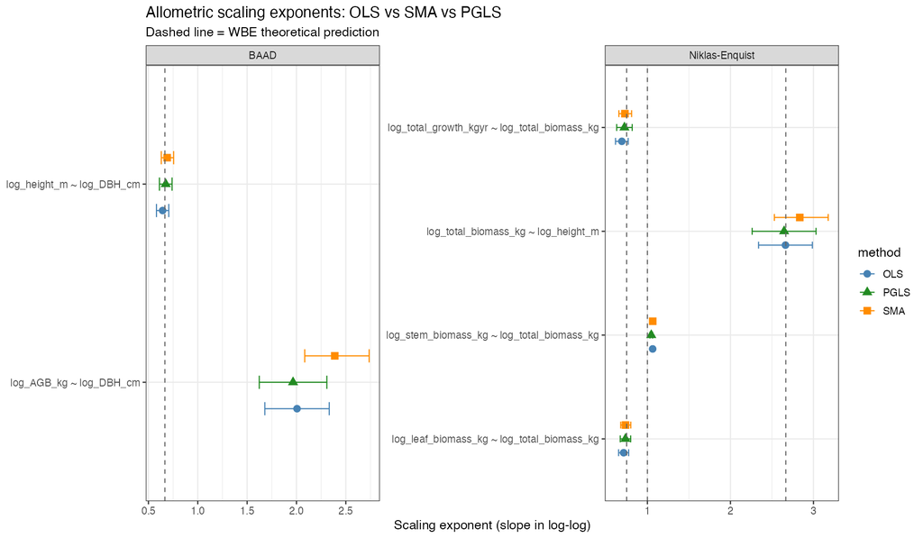

Forest plot of allometric scaling exponents. Points = estimated slope; error bars = 95% CI; dashed line = WBE theoretical prediction. OLS (blue), SMA (orange), PGLS (green).

```r
forest_path <- file.path(proj_dir, "output/forest_plot_slopes.png")
if (file.exists(forest_path)) {
  knitr::include_graphics(forest_path)
} else {
  message("forest_plot_slopes.png not found — run scripts/06_pgls_allometry.R first.")
}
```

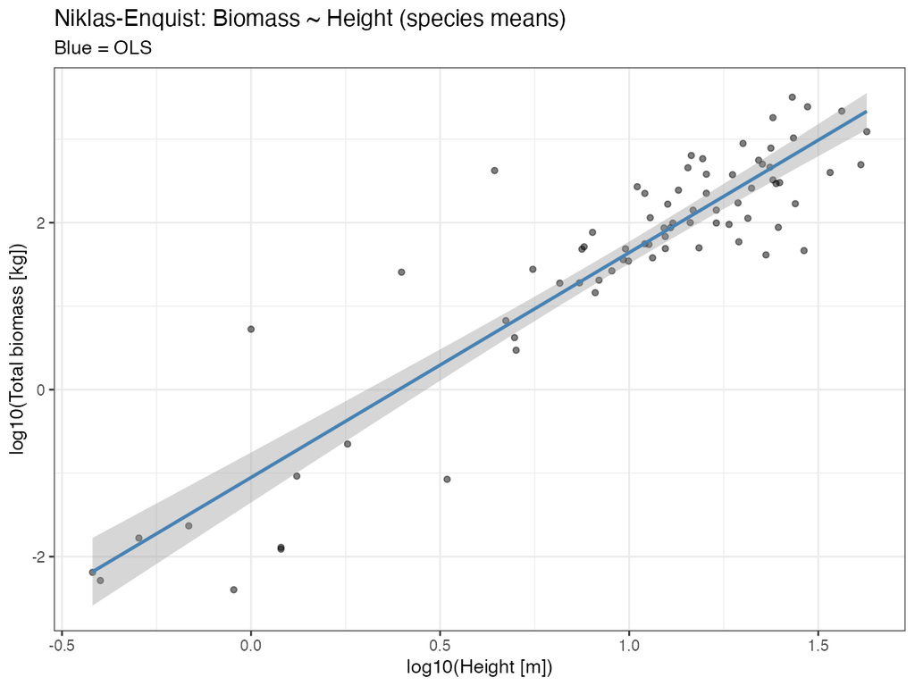

Niklas-Enquist species means: log10(Total biomass [kg]) ~ log10(Height [m]). Blue line = OLS fit with 95% confidence band.

```r
scatter_path <- file.path(proj_dir, "output/scatter_ne_biomass_height.png")
if (file.exists(scatter_path)) {
  knitr::include_graphics(scatter_path)
} else {
  message("scatter_ne_biomass_height.png not found — run scripts/06_pgls_allometry.R first.")
}
```

# 6 Interpretation

## 6.1 OLS vs PGLS Slope Differences

When the PGLS slope differs from the OLS slope, this indicates that clade-level body size stratification is influencing the estimate. PGLS down-weights within-clade replication through the phylogenetic variance-covariance matrix: species that share a recent common ancestor are treated as partially redundant observations. A PGLS slope that is shallower than OLS is consistent with the interpretation that the OLS slope partly reflects between-clade body size diversification (e.g., the contrast between large-bodied trees and small-bodied herbs) rather than a constraint operating within lineages.

## 6.2 Pagel’s Lambda Interpretation

The ML-estimated λ in PGLS residuals indicates how much of the unexplained biomass variation is phylogenetically conserved. λ near 1 means residuals follow the Brownian motion expectation — traits have diverged proportionally to branch length. This is expected for architectural traits such as wood density, crown geometry, and height–diameter ratios, which differ substantially among major plant clades (gymnosperms vs. angiosperms, monocots vs. eudicots). When λ is high, OLS standard errors are anti-conservative and p-values should be interpreted with caution.

## 6.3 WBE Theory Evaluation

The recovery of exponents close to WBE predictions (8/3 for biomass ~ height, 3/4 for growth ~ biomass) in OLS regressions of cross-species data is consistent with the theory but does not uniquely confirm it. The same exponents are predicted by several alternative models and may also arise from between-clade body size diversification rather than from the fractal vascular network constraint WBE postulated. PGLS provides a more conservative test because it partially removes the among-clade signal. If the PGLS exponent still matches the WBE prediction, that constitutes stronger within-lineage support.

## 6.4 Dataset Caveats

> **⚠ WARNING: Clade bias** — The Niklas-Enquist dataset is derived substantially from Cannell (1982) and overrepresents temperate deciduous trees and conifers. Conclusions may not generalize to tropical broadleaf species or herbaceous taxa.

> **⚠ WARNING: Growth rate measurement** — Growth rates in Niklas-Enquist are annual net biomass increment period averages, not instantaneous metabolic rates. The test of $dM/dt \propto M^{3/4}$ is an approximation; net production ≠ gross metabolic rate.

# 7 Methods

Allometric scaling was analysed for two datasets. The **Niklas-Enquist** database (~2,626 records) compiles cross-species biomass measurements primarily from Cannell (1982) with additional primary literature records; see Niklas & Enquist (2001) *PNAS* 98:2922-2927 and Enquist & Niklas (2002) *Science* 295:1517-1520. The **BAAD** database (~21,084 individual-level records) is described in Falster et al. (2015) *Scientific Data* 2:150034 (https://doi.org/10.1038/sdata.2015.34).

Both datasets were aggregated to species means by taking arithmetic means of log10-transformed trait values (equivalent to geometric means). Only species present in both the dataset and the phylogeny were retained for PGLS.

The phylogeny is the Smith & Brown (2018) GBOTB seed plant megatree, pruned to study species using V.PhyloMaker2 (Scenario 2). Citation: Smith SA & Brown JW (2018) Constructing a broadly inclusive seed plant phylogeny. *American Journal of Botany* 105(3):302-314. DOI: 10.1002/ajb2.1019. **Note: this citation should be verified independently before any manuscript use.**

# 8 Pipeline Run Order

> **Required execution order before knitting this report:**
> 1. `Rscript scripts/04_prepare_pgls_species_means.R` — aggregate species means
> 2. `Rscript scripts/05_build_phylogeny_smith2018.R` — build pruned tree (requires V.PhyloMaker2)
> 3. `Rscript scripts/06_pgls_allometry.R` — run OLS / SMA / PGLS regressions
> 4. Knit this Rmd

> All scripts should be run from the `plant_scaling_data/` directory. Outputs are written to `data/processed/` and `output/`.

```r
cat("Analysis date:", format(Sys.Date()), "\n")
```

```
## Analysis date: 2026-05-02
```

```r
R.Version()$version.string
```

```
## [1] "R version 4.3.3 (2024-02-29)"
```

```r
tryCatch(cat("V.PhyloMaker2 version:", as.character(packageVersion("V.PhyloMaker2")), "\n"), error=function(e) NULL)
```

```
## V.PhyloMaker2 version: 0.1.0
```

```r
tryCatch(cat("caper version:", as.character(packageVersion("caper")), "\n"), error=function(e) NULL)
```

```
## caper version: 1.0.3
```